# Pendugaan Parameter, Diagnostik Model, dan Peramalan

Rani Yasmin Azzahra

2023-10-16

## Packages

```r
library(ggplot2)
library(tsibble)
library(tseries)
library(MASS)
library(forecast)
library(TSA)
library(TTR)
library(aTSA)
library(graphics)
```

## Input Data

```r
df <- rio::import("https://raw.githubusercontent.com/raniysmnz/MPDW/main/Data/Kurs_JPY_PT2123.csv")
str(df)
```

```
## 'data.frame':    489 obs. of  2 variables:
##  $ Time Period: int  1 2 3 4 5 6 7 8 9 10 ...
##  $ Kurs Jual  : num  13084 13009 13049 13034 13025 ...
```

## Pembagian Data

Data akan dibagi dengan perbandingan 80:20 untuk data train:test

```r
kurs <- df$`Kurs Jual`
train <- kurs[1:391]
test <- kurs[392:489]
train <- ts(train)
```

## Eksplorasi Data

Sebelum masuk dalam tahap pemodelan, dilakukan eksplorasi data dengan plot deret waktu untuk melihat pola data.

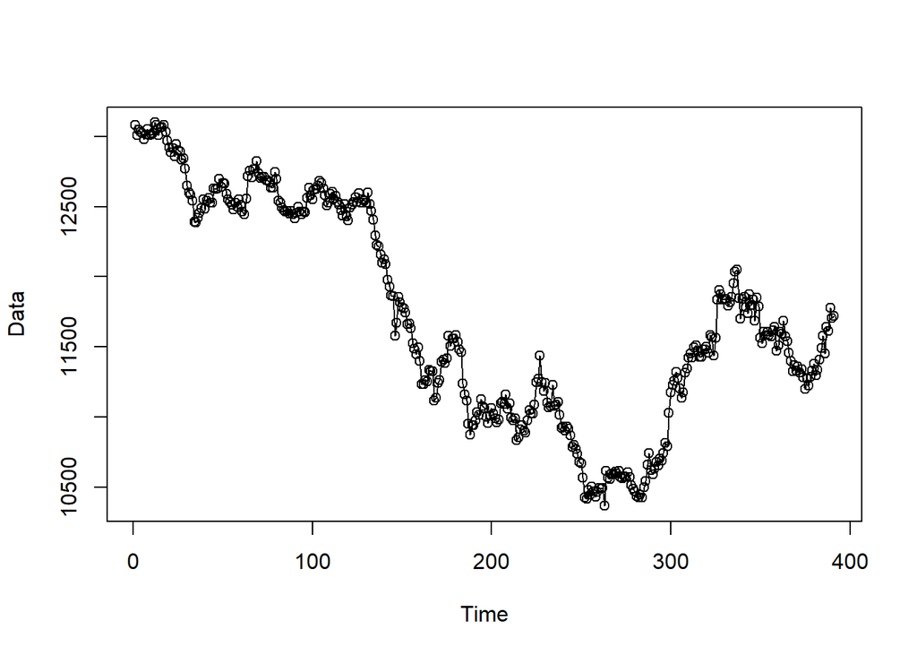

```r
#--PLOT TIME SERIES--#
plot(train,
     lwd = 1,
     type = "o",
     xlab = "Time",
     ylab = "Data")
```

```r
mean(train)
```

```
## [1] 11720.35
```

## Cek Stasioner

### Plot ACF

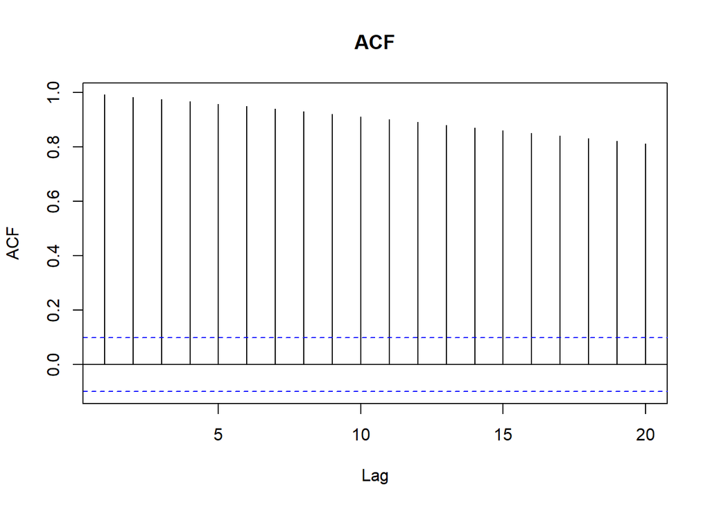

```r
#--CEK KESTASIONERAN---#
acf(train, main="ACF", lag.max=20)
```

Berdasarkan plot ACF di atas, dapat dilihat bahwa plot menurun secara perlahan menandakan data tidak stasioner dalam rataan.

### Uji ADF (Stasioner Rataan)

```r
adf.test(train)
```

```
## Augmented Dickey-Fuller Test
## alternative: stationary
##
## Type 1: no drift no trend
##      lag    ADF p.value
## [1,]   0 -1.058   0.301
## [2,]   1 -0.988   0.326
## [3,]   2 -1.051   0.303
## [4,]   3 -0.987   0.326
## [5,]   4 -0.904   0.356
## [6,]   5 -0.851   0.375
## Type 2: with drift no trend
##      lag   ADF p.value
## [1,]   0 -1.76   0.421
## [2,]   1 -1.68   0.454
## [3,]   2 -1.73   0.433
## [4,]   3 -1.72   0.438
## [5,]   4 -1.74   0.430
## [6,]   5 -1.71   0.445
## Type 3: with drift and trend
##      lag    ADF p.value
## [1,]   0 -0.844   0.957
## [2,]   1 -0.826   0.959
## [3,]   2 -0.767   0.964
## [4,]   3 -0.838   0.958
## [5,]   4 -0.990   0.940
## [6,]   5 -1.003   0.938
## ----
## Note: in fact, p.value = 0.01 means p.value <= 0.01
```

$H_0$ : Data tidak stasioner dalam rataan

$H_1$ : Data stasioner dalam rataan

Berdasarkan uji ADF tersebut, didapat *p-value* sebesar 0.938 yang lebih besar dari taraf nyata 5% sehingga terima $H_0$ dan menandakan bahwa data tidak stasioner dalam rataan. Hal ini sesuai dengan hasil eksplorasi menggunakan plot time series dan plot ACF.

### Plot Box Cox (Stasioner Ragam)

```r
index <- seq(1:391)
bc = MASS::boxcox(train~index, lambda = seq(-4,12,by=1))
```

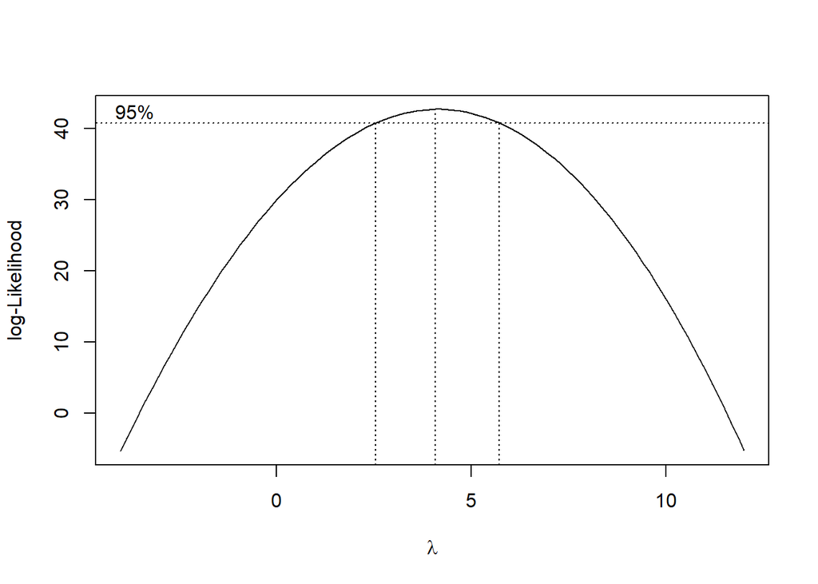

```r
#Nilai Rounded Lambda
lambda <- bc$x[which.max(bc$y)]
lambda
```

```
## [1] 4.080808
```

```r
#SK
bc$x[bc$y > max(bc$y) - 1/2 * qchisq(.95,1)]
```

```
##  [1] 2.626263 2.787879 2.949495 3.111111 3.272727 3.434343 3.595960 3.757576
##  [9] 3.919192 4.080808 4.242424 4.404040 4.565657 4.727273 4.888889 5.050505
## [17] 5.212121 5.373737 5.535354 5.696970
```

Plot di atas menunjukkan nilai rounded value (λ) optimum sebesar 4.080808 dan pada selang kepercayaan 95% nilai memiliki batas bawah 2.626263 dan batas atas 5.696970. Selang tersebut tidak memuat nilai satu sehingga dapat dikatakan bahwa data bangkitan tidak stasioner dalam ragam.

## Penanganan Ketidakstasioneran Data

### Differencing Ordo 1

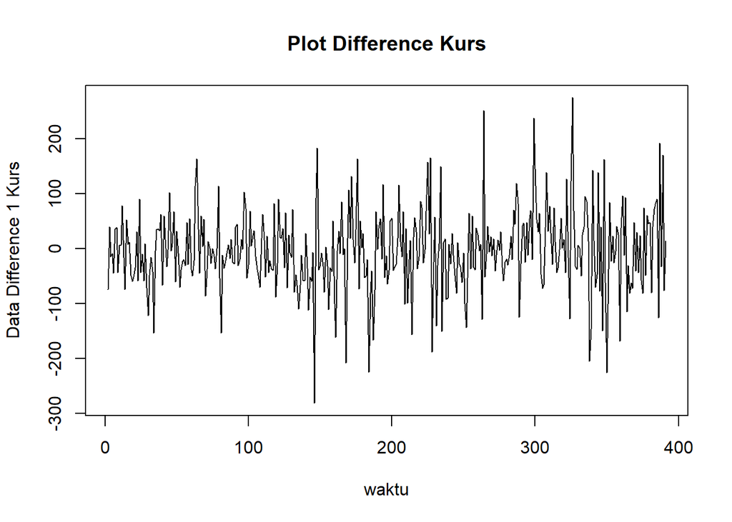

```r
train.diff <- diff(train, differences = 1)
plot.ts(train.diff, lty=1, xlab="waktu", ylab="Data Difference 1 Kurs", main="Plot Difference Kurs")
```

Berdasarkan plot data deret waktu, terlihat bahwa data sudah stasioner dalam rataan ditandai dengan data bergerak pada nilai tengah tertentu (tidak terdapat trend ataupun musiman pada data).

### Uji ADF (Stasioner Rataan)

```r
tseries::adf.test(train.diff)
```

```
##
##  Augmented Dickey-Fuller Test
##
## data:  train.diff
## Dickey-Fuller = -6.388, Lag order = 7, p-value = 0.01
## alternative hypothesis: stationary
```

$H_0$ : Data tidak stasioner dalam rataan

$H_1$ : Data stasioner dalam rataan

### Plot ACF dan PACF

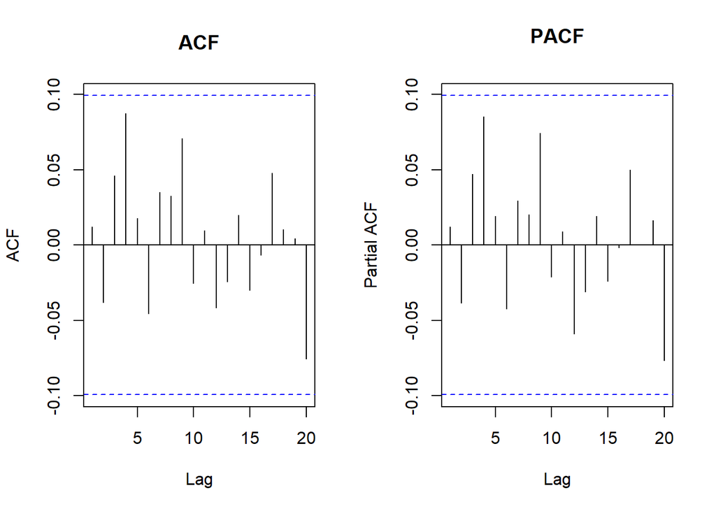

```r
#---SPESIFIKASI MODEL---#
par(mfrow = c(1,2))
acf(train.diff, main="ACF", lag.max=20)
pacf(train.diff, main="PACF", lag.max=20)
```

```r
par(mfrow = c(1,1))
```

Tidak terdapat cut off/tails off pada kedua plot sehingga tidak dapat ditentukan model regresi time series pada data. Akan dilakukan differencing 2 untuk menanganinnya.

### Differencing Ordo 2

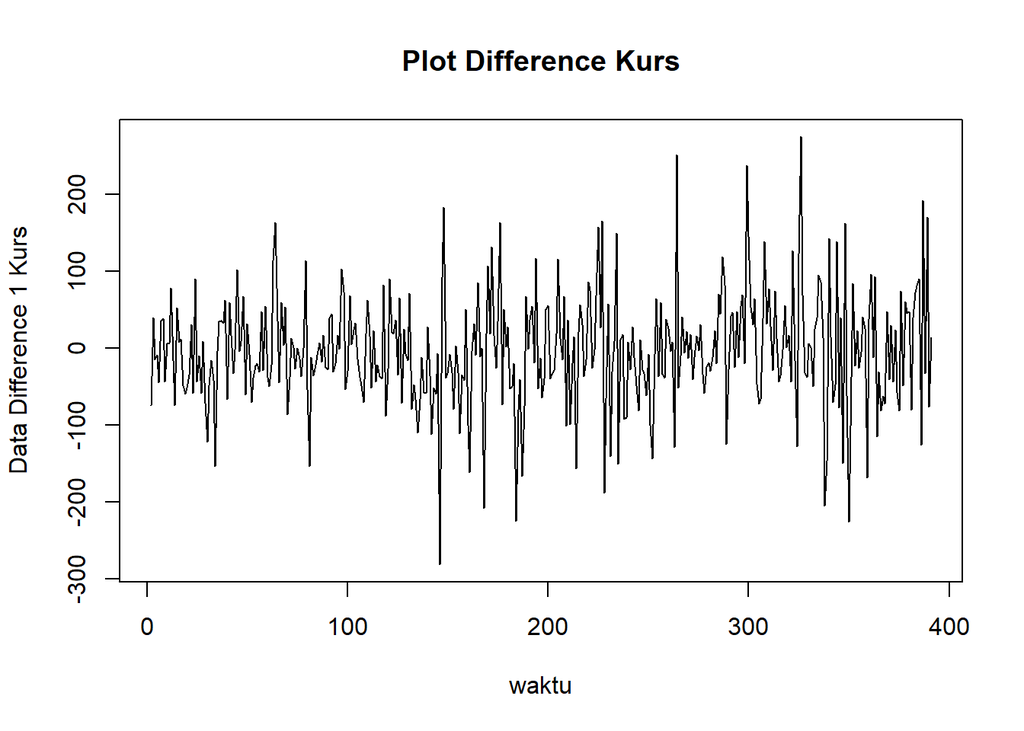

```r
train.diff.2 <- diff(train, differences = 2)
plot.ts(train.diff, lty=1, xlab="waktu", ylab="Data Difference 1 Kurs", main="Plot Difference Kurs")
```

### Uji ADF (Stasioner Rataan)

```r
tseries::adf.test(train.diff.2)
```

```
##
##  Augmented Dickey-Fuller Test
##
## data:  train.diff.2
## Dickey-Fuller = -12.437, Lag order = 7, p-value = 0.01
## alternative hypothesis: stationary
```

$H_0$ : Data tidak stasioner dalam rataan

$H_1$ : Data stasioner dalam rataan

## Identifikasi Model Regresi Time Series

### Plot ACF dan PACF

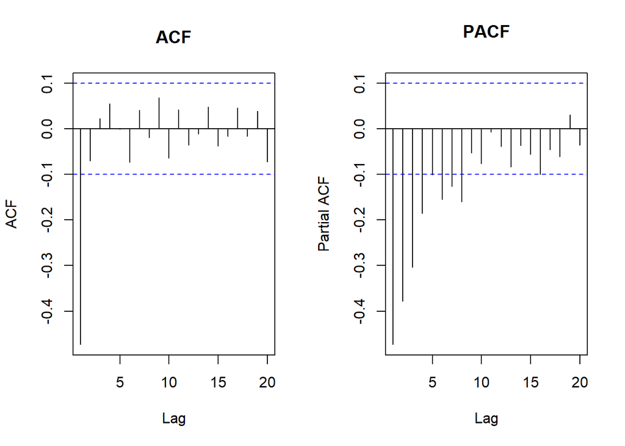

```r
#---SPESIFIKASI MODEL---#
par(mfrow = c(1,2))
acf(train.diff.2, main="ACF", lag.max=20)
pacf(train.diff.2, main="PACF", lag.max=20)
```

```r
par(mfrow = c(1,1))
```

Plot ACF cut off pada lag ke-1 sedangkan pada plot PACF tails off. Dapat diasumsikan model yang terbentuk adalah ARIMA(0,2,1). Selain dengan plot ACF dan PACF, penentuan spesifikasi model dilakukan dengan *extended ACF* (EACF) berikut ini.

### Plot EACF

```r
eacf(train.diff.2)
```

```
## AR/MA
##   0 1 2 3 4 5 6 7 8 9 10 11 12 13
## 0 x o o o o o o o o o o  o  o  o
## 1 x x o o o o o o o o o  o  o  o
## 2 x x x o o o o o o o o  o  o  o
## 3 x x o x o o o o o o o  o  o  o
## 4 x o x x o o o o o o o  o  o  o
## 5 x x o x x x o o o o o  o  o  o
## 6 x x o x x x x o o o o  o  o  o
## 7 x x x x x o x o o o o  o  o  o
```

```r
#ARIMA(0,2,1) #ARIMA(1,2,2) #ARIMA(0,2,2)
#Terdapat 3 model tentatif
```

Menggunakan plot EACF, dapat diambil beberapa model dengan melihat ujung segitiga yang terbentuk, antara lain ARIMA(0,2,1), ARIMA(1,2,2), dan ARIMA(0,2,2).

## Pendugaan Parameter Model Tentatif

Selanjutnya akan dilakukan pendugaan parameter ketiga model ARIMA yang terbentuk sebelumnya. Pendugaan dilakukan dengan fungsi `Arima()` yang dilanjutkan dengan melihat nilai AIC pada ringkasan data dan melihat signifikansi parameter.

### ARIMA (0,2,1)

```r
model1 = Arima(train.diff.2, order=c(0,2,1), method="ML")
summary(model1) #AIC = 5114.95
```

```
## Series: train.diff.2
## ARIMA(0,2,1)
##
## Coefficients:
##           ma1
##       -1.0000
## s.e.   0.0064
##
## sigma^2 = 31442:  log likelihood = -2555.48
## AIC=5114.95   AICc=5114.98   BIC=5122.87
##
## Training set error measures:
##                    ME     RMSE      MAE     MPE     MAPE      MASE       ACF1
## Training set 2.179562 176.6339 133.1024 112.762 333.7659 0.9962479 -0.6321144
```

```r
lmtest::coeftest(model1) #hanya parameter MA1 yang signifikan
```

```
##
## z test of coefficients:
##
##       Estimate Std. Error z value  Pr(>|z|)
## ma1 -0.9999998  0.0064085 -156.04 < 2.2e-16 ***
## ---
## Signif. codes:  0 '***' 0.001 '**' 0.01 '*' 0.05 '.' 0.1 ' ' 1
```

### ARIMA (1,2,2)

```r
model2 = Arima(train.diff.2, order=c(1,2,2), method="ML")
summary(model2) #AIC = 4616.84
```

```
## Series: train.diff.2
## ARIMA(1,2,2)
##
## Coefficients:
##           ar1      ma1     ma2
##       -0.4677  -1.9981  0.9996
## s.e.   0.0448   0.0103  0.0102
##
## sigma^2 = 8356:  log likelihood = -2304.42
## AIC=4616.84   AICc=4616.95   BIC=4632.68
##
## Training set error measures:
##                    ME     RMSE      MAE      MPE     MAPE      MASE       ACF1
## Training set 1.133747 90.82382 68.11831 104.0786 164.7728 0.5098533 -0.1775608
```

```r
lmtest::coeftest(model2) #parameter AR1, MA1, MA2 signifikan
```

```
##
## z test of coefficients:
##
##      Estimate Std. Error  z value  Pr(>|z|)
## ar1 -0.467706   0.044796  -10.441 < 2.2e-16 ***
## ma1 -1.998145   0.010259 -194.777 < 2.2e-16 ***
## ma2  0.999643   0.010237   97.646 < 2.2e-16 ***
## ---
## Signif. codes:  0 '***' 0.001 '**' 0.01 '*' 0.05 '.' 0.1 ' ' 1
```

### ARIMA (0,2,2)

```r
model3 = Arima(train.diff.2, order=c(0,2,2), method="ML")
summary(model3) #AIC = 4711.14
```

```
## Series: train.diff.2
## ARIMA(0,2,2)
##
## Coefficients:
##           ma1     ma2
##       -1.9976  0.9998
## s.e.   0.0093  0.0090
##
## sigma^2 = 10747:  log likelihood = -2352.57
## AIC=4711.14   AICc=4711.2   BIC=4723.01
##
## Training set error measures:
##                    ME     RMSE      MAE      MPE     MAPE      MASE       ACF1
## Training set 1.558976 103.1339 77.97217 107.7108 109.0847 0.5836077 -0.4675552
```

```r
lmtest::coeftest(model3) #hanya parameter MA1 MA2 yang signifikan
```

```
##
## z test of coefficients:
##
##       Estimate Std. Error z value  Pr(>|z|)
## ma1 -1.9976265  0.0092618 -215.68 < 2.2e-16 ***
## ma2  0.9997667  0.0090498  110.47 < 2.2e-16 ***
## ---
## Signif. codes:  0 '***' 0.001 '**' 0.01 '*' 0.05 '.' 0.1 ' ' 1
```